# In-Class Session 1: Probability, Operators, and the Big Theorems

Econometrics I

This notebook reproduces the code from Lecture 1 and leaves you three short problems. Run every chunk yourself. Nothing here requires more than base R and `MASS`.

# Reproduce: distributions from the slides

The normal CDF and PDF (the slides used `ggplot2`; base R’s `curve` does fine):

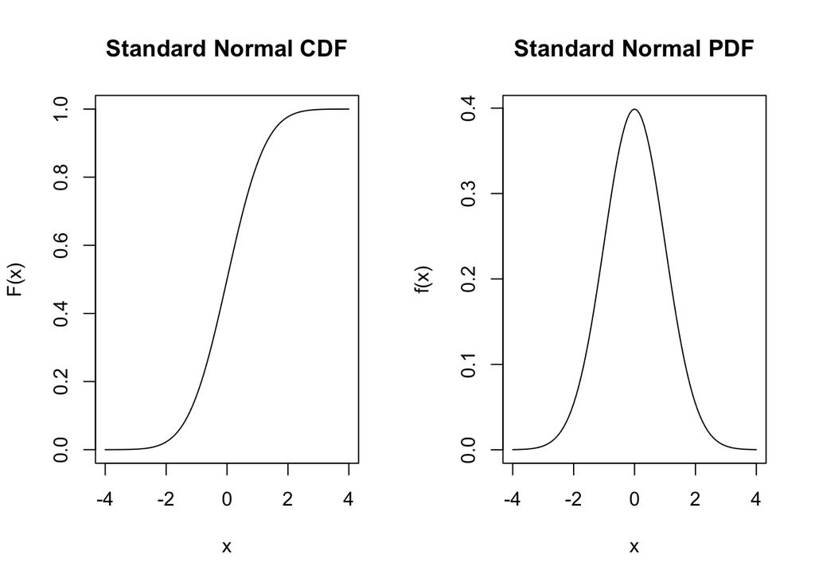

```r
par(mfrow = c(1, 2))
curve(pnorm(x), from = -4, to = 4, main = "Standard Normal CDF", ylab = "F(x)")
curve(dnorm(x), from = -4, to = 4, main = "Standard Normal PDF", ylab = "f(x)")
```

# Reproduce: the Bayes / rare disease calculation

A test has a 5% false positive rate and a 0% false negative rate. If 1% of the population has the disease, what is the probability a positive test means disease?

```r
posterior <- function(prevalence, fpr = 0.05, fnr = 0.00) {
  p_pos <- (1 - fnr) * prevalence + fpr * (1 - prevalence)
  (1 - fnr) * prevalence / p_pos
}
posterior(0.01)     # 1% prevalence
```

```
## [1] 0.1680672
```

```r
posterior(0.0005)   # 0.05% prevalence: "think horses, not zebras"
```

```
## [1] 0.009905894
```

# Reproduce: the variance of a sample mean, from the operator rules

In lecture we derived $Var(\bar{X}_n) = \sigma^2/n$ using only linearity and the variance rules. Let’s watch the derivation be true:

```r
n <- 25; sigma2 <- 4
means <- replicate(2000, mean(rnorm(n, mean = 0, sd = sqrt(sigma2))))
c(simulated = var(means), predicted = sigma2 / n)
```

```
## simulated predicted
## 0.1624133 0.1600000
```

# Reproduce: a computer draws a random variable through the quantile function

```r
u <- runif(5)
cbind(qnorm(u), {set.seed(1); qnorm(runif(5))}, {set.seed(1); rnorm(5)})[, 2:3]
```

```
##            [,1]       [,2]
## [1,] -0.6264538 -0.6264538
## [2,] -0.3262334  0.1836433
## [3,]  0.1836433 -0.8356286
## [4,]  1.3297993  1.5952808
## [5,] -0.8356286  0.3295078
```

```r
x <- qnorm(runif(10000))
c(mean = mean(x), sd = sd(x), q975 = quantile(x, 0.975))
```

```
##          mean            sd    q975.97.5%
## -0.0002734991  1.0106664451  1.9823129697
```

# Reproduce: probabilities are expectations of indicators

```r
x <- rnorm(10000)
c(mean_of_indicator = mean(x > 1.96), true_prob = 1 - pnorm(1.96))
```

```
## mean_of_indicator         true_prob
##         0.0224000         0.0249979
```

```r
d <- rbinom(10000, 1, 0.3); y <- 5 + 2 * d + rnorm(10000)
c(direct = mean(y[d == 1]), via_indicator = mean(y * (d == 1)) / mean(d == 1))
```

```
##        direct via_indicator
##      6.995123      6.995123
```

# Reproduce: uncorrelated is not independent

$X$ is symmetric, $Y = X^2$. The correlation is zero and $Y$ is a deterministic function of $X$.

```r
x <- rnorm(10000); y <- x^2
cor(x, y)
```

```
## [1] -0.01312371
```

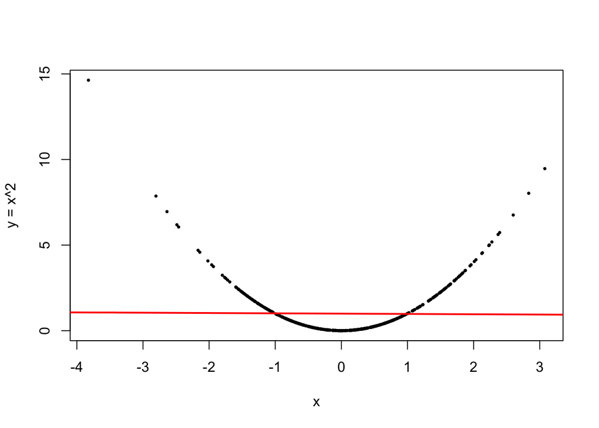

```r
plot(x[1:500], y[1:500], pch = 16, cex = 0.5, xlab = "x", ylab = "y = x^2")
abline(lm(y ~ x), col = "red", lwd = 2)          # the best *linear* predictor is flat
```

# Reproduce: the linear projection is what OLS estimates

Even when the conditional expectation is not linear, OLS recovers $Cov(X,Y)/Var(X)$:

```r
x <- runif(10000, 0, 2); y <- exp(x) + rnorm(10000, sd = 0.3)   # nonlinear CEF
c(projection = cov(x, y) / var(x), ols = unname(coef(lm(y ~ x))[2]))
```

```
## projection        ols
##   3.001022   3.001022
```

# Reproduce: LLN and CLT histograms

The Bernoulli sample-mean histograms from Lecture 1b:

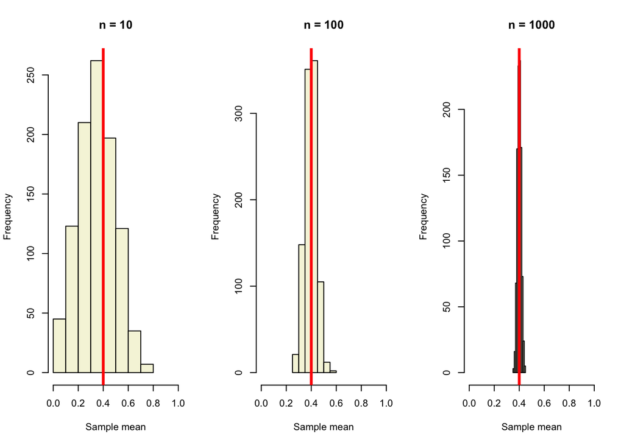

```r
lln_plot <- function(n, p = 0.4) {
  means <- rbinom(1000, n, p) / n
  hist(means, xlim = c(0, 1), col = "beige", main = paste0("n = ", n),
       xlab = "Sample mean")
  abline(v = p, lwd = 3, col = "red")
}
par(mfrow = c(1, 3))
for (n in c(10, 100, 1000)) lln_plot(n)
```

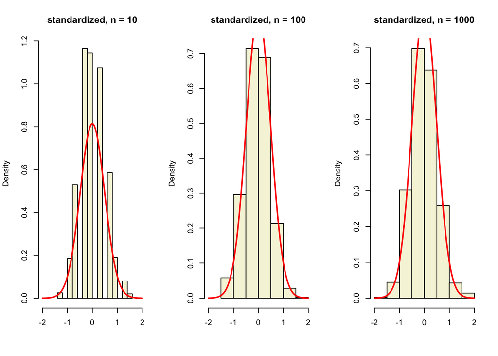

```r
clt_plot <- function(n, p = 0.4) {
  z <- (rbinom(1000, n, p) / n - p) * sqrt(n)
  hist(z, xlim = c(-2, 2), col = "beige", freq = FALSE,
       main = paste0("standardized, n = ", n), xlab = "")
  curve(dnorm(x, sd = sqrt(p * (1 - p))), add = TRUE, lwd = 2, col = "red")
}
par(mfrow = c(1, 3))
for (n in c(10, 100, 1000)) clt_plot(n)
```

# Reproduce: bias squared plus variance

From Lecture 1b: shrink the sample mean toward zero, $\hat\theta_\lambda = (1-\lambda)\bar X$, and watch the unbiased choice $\lambda = 0$ lose on mean squared error.

```r
mu <- 1; sigma <- 3; n <- 20
xbar <- replicate(5000, mean(rnorm(n, mu, sigma)))
mse <- sapply(c(0, 0.1, 0.2, 0.3, 0.4, 0.5), function(l) mean(((1 - l) * xbar - mu)^2))
rbind(lambda = c(0, 0.1, 0.2, 0.3, 0.4, 0.5), mse = round(mse, 3),
      formula = round((c(0, 0.1, 0.2, 0.3, 0.4, 0.5) * mu)^2 + (1 - c(0, 0.1, 0.2, 0.3, 0.4, 0.5))^2 * sigma^2 / n, 3))
```

```
##          [,1]  [,2]  [,3]  [,4]  [,5]  [,6]
## lambda  0.000 0.100 0.200 0.300 0.400 0.500
## mse     0.435 0.362 0.317 0.302 0.315 0.357
## formula 0.450 0.375 0.328 0.310 0.322 0.362
```

# In-class problem 1: diversification is a variance rule

Two assets have returns with standard deviation 10% each and correlation $\rho$. From the operator rules, the equal-weighted portfolio has variance $\sigma^2(1+\rho)/2$.

**(a)** Simulate 10,000 pairs of returns with $\rho = 0.9$ (use `MASS::mvrnorm`), form the portfolio return, and compare its variance to the formula. **(b)** Repeat for $\rho = -0.9$. What happened, and why is this “the entire logic of diversification” in one number?

```r
library(MASS)
# your code here
```

# In-class problem 2: mean independent, or just uncorrelated?

Let $X \sim \mathcal{N}(0,1)$ and $\varepsilon = X^2 - 1$ (so $\mathbb{E}[\varepsilon] = 0$).

**(a)** Verify by simulation that $Cov(X, \varepsilon) = 0$. **(b)** Compute $\mathbb{E}[\varepsilon \mid X > 1]$ and $\mathbb{E}[\varepsilon \mid |X| < 0.5]$ from the simulated data. Is $\varepsilon$ mean independent of $X$? **(c)** One sentence: if $\varepsilon$ were the error in a regression of $Y$ on $X$, which of the two assumptions from lecture would hold, and why does it matter which?

```r
# your code here
```

# In-class problem 3: total variance in a customer base

A subscription business has two customer segments. Segment A (30% of customers) spends $\sim \mathcal{N}(80, 10^2)$ per month; segment B (70%) spends $\sim \mathcal{N}(40, 20^2)$.

**(a)** Simulate 10,000 customers. Compute the total variance of spending. **(b)** Compute the two pieces of the law of total variance — the average *within*-segment variance and the variance of the segment *means* — and verify they sum to (a). **(c)** One sentence: if you could only report one of the two pieces to describe “how different are our customers,” which would you pick and why?

```r
# your code here
```